# Worksheet_8

## Worksheet 8

#### Student Name: Jeevitha Bandi

## Exercise 1: Clustering "By Hand"

Following the example in the lecture slides, complete k-means iterations "by hand". Leave any computations you complete here.

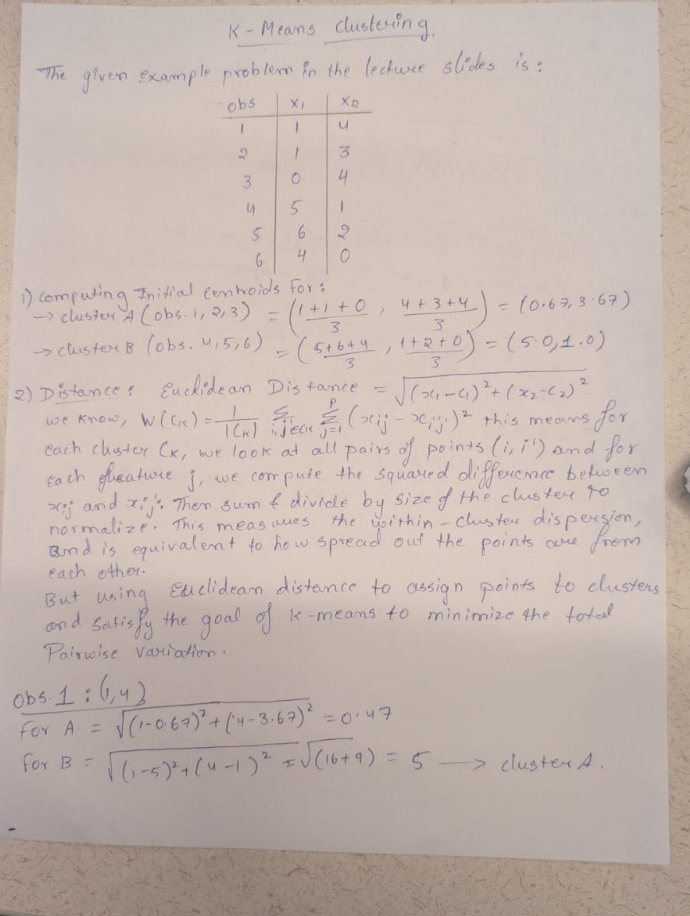

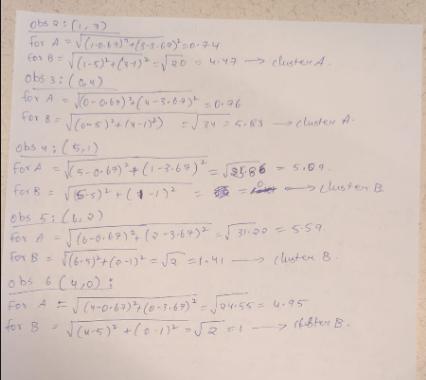

## Exercise 2: Clustering the Colleges Data

Using the `College` data set from the ISLP library, demonstrate the use of SVD/PCA and clustering. Documentation can be found [here](https://islp.readthedocs.io/en/latest/datasets/College.html) and the dataset can be downloaded from the ISLP package or [this hosted csv.](https://raw.githubusercontent.com/intro-stat-learning/ISLP/refs/heads/main/ISLP/data/College.csv)

(a) Save the college data without the `Private` variable. Scale the data to be zero mean and unit variance.

```python
from ISLP import load_data
from sklearn.preprocessing import StandardScaler
import pandas as pd

clg = load_data('College')

# Removing the 'Private' column
X = clg.drop(columns=['Private'])
# Since its unsupervised learning (clustering), so we don’t want to use any labels or target variables during the clustering process.

# Standardizing
scaler = StandardScaler()
X_scaled = scaler.fit_transform(X)

# Convert the scaled NUmpy array to DataFrame making it easier to analyze and plot
X_scaled_df = pd.DataFrame(X_scaled, columns=X.columns, index=clg.index)
X_scaled_df.head()
```

|  | Apps | Accept | Enroll | Top10perc | Top25perc | F.Undergrad | P.Undergrad | Outstate | Room.Board | Books | Personal | PhD | Terminal | S.F.Ratio | perc.alumni | Expend | Grad.Rate |
| --- | --- | --- | --- | --- | --- | --- | --- | --- | --- | --- | --- | --- | --- | --- | --- | --- | --- |
| 0 | -0.346882 | -0.321205 | -0.063509 | -0.258583 | -0.191827 | -0.168116 | -0.209207 | -0.746356 | -0.964905 | -0.602312 | 1.270045 | -0.163028 | -0.115729 | 1.013776 | -0.867574 | -0.501910 | -0.318252 |
| 1 | -0.210884 | -0.038703 | -0.288584 | -0.655656 | -1.353911 | -0.209788 | 0.244307 | 0.457496 | 1.909208 | 1.215880 | 0.235515 | -2.675646 | -3.378176 | -0.477704 | -0.544572 | 0.166110 | -0.551262 |
| 2 | -0.406866 | -0.376318 | -0.478121 | -0.315307 | -0.292878 | -0.549565 | -0.497090 | 0.201305 | -0.554317 | -0.905344 | -0.259582 | -1.204845 | -0.931341 | -0.300749 | 0.585935 | -0.177290 | -0.667767 |
| 3 | -0.668261 | -0.681682 | -0.692427 | 1.840231 | 1.677612 | -0.658079 | -0.520752 | 0.626633 | 0.996791 | -0.602312 | -0.688173 | 1.185206 | 1.175657 | -1.615274 | 1.151188 | 1.792851 | -0.376504 |
| 4 | -0.726176 | -0.764555 | -0.780735 | -0.655656 | -0.596031 | -0.711924 | 0.009005 | -0.716508 | -0.216723 | 1.518912 | 0.235515 | 0.204672 | -0.523535 | -0.553542 | -1.675079 | 0.241803 | -2.939613 |

The output have all features have mean = 0 and std = 1

(b) Perform k-means clustering on the data with 2 clusters, making sure to use more than 1 iteration of initializing. Plot the clusters in color on a scatter plot of any two variables you want. What is the total within-group sum of squares?

```python
from sklearn.cluster import KMeans # to perform clustering
import matplotlib.pyplot as plt
import seaborn as sns

# Performing KMeans with 2 clusters and multiple initializations
kmeans = KMeans(n_clusters=2, n_init=10, random_state=42) # wanting 2 groups to mimic public vs private clg and runs the algorithm 10 times with different centroids since KMeans is sensitive to starting points
clusters = kmeans.fit_predict(X_scaled_df)# to know which cluster each clg falls into, we assign each row a cluster label 0/1

# Adding the cluster labels to the DataFrame for plotting
X_scaled_df['Cluster'] = clusters
```

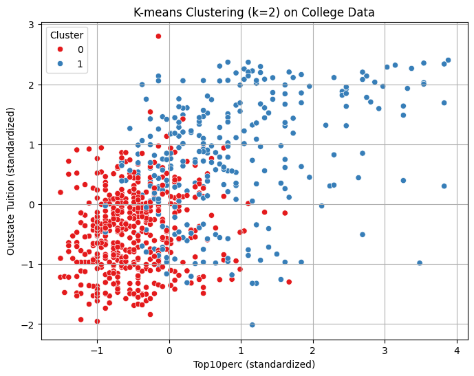

```python
plt.figure(figsize=(8, 6))
sns.scatterplot(data=X_scaled_df, x='Top10perc', y='Outstate', hue='Cluster', palette='Set1')
plt.title('K-means Clustering (k=2) on College Data')
plt.xlabel('Top10perc (standardized)')
plt.ylabel('Outstate Tuition (standardized)')
plt.legend(title='Cluster')
plt.grid(True)
plt.show()
```

```python
# Printing WCSS (inertia_) — how tightly grouped the points in each cluster are
print("Total Within-Cluster Sum of Squares (WCSS):", kmeans.inertia_)
#Lower WCSS = better clustering (to a point), It’s useful for evaluating and comparing results
```

```
Total Within-Cluster Sum of Squares (WCSS): 10469.53468352414
```

**Plot Interpretation**

I plotted the standardized Top 10% of students against Out-of-State Tuition and highlighted the data points according to their respective clusters:

**Cluster 0 (red)** identifies colleges that tend to have:

- A lower percentage of students from the top 10% of their class.
- Reduced out-of-state tuition fees.
- A likelihood of being less selective, often categorized as public colleges.

**Cluster 1 (blue)** encompasses:

- Colleges with a higher proportion of students hailing from the top 10%.
- Increased out-of-state tuition costs.
- A tendency to be more prestigious or primarily private institutions.

**WCSS Result**

The Total Within-Cluster Sum of Squares (WCSS) is 10469.53. This metric helps assess how tightly packed the clusters are. Since standardized data is employed, this provides a solid baseline.

As we experiment with different values of k later on, a lower WCSS could indicate better clustering. However, it's essential to strike a balance with interpretability, which we'll explore further in part f with the elbow and silhouette methods.

(c) Run a singular value decomposition on the college data. Plot and interpret the proportion of variance explained.

To perform Singular Value Decomposition (SVD), also known as Principal Component Analysis (PCA), on the standardized data, and to visualize the variance explained by each component.

This process helps us understand:

1. Which directions in the feature space (principal components) capture the most information.
2. Whether dimensionality reduction could be beneficial.

```python
from sklearn.decomposition import TruncatedSVD
import numpy as np

# Dropping the non-feature column ('Cluster') before applying SVD
X_for_svd = X_scaled_df.drop(columns=['Cluster'])
# Applying SVD (PCA) on standardized data
# Choosing enough components to capture most of the variance (say, 17 for 17 features)
svd = TruncatedSVD(n_components=X_for_svd.shape[1], random_state=42)
svd_fit = svd.fit(X_for_svd)

# Explained variance ratio
explained_var_ratio = svd_fit.explained_variance_ratio_
```

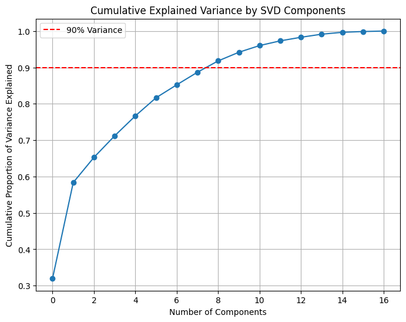

```python
# Plotting the proportion of variance explained by each singular vector (component)
plt.figure(figsize=(8, 6))
plt.plot(np.cumsum(explained_var_ratio), marker='o')
plt.title('Cumulative Explained Variance by SVD Components')
plt.xlabel('Number of Components')
plt.ylabel('Cumulative Proportion of Variance Explained')
plt.grid(True)
plt.axhline(y=0.9, color='r', linestyle='--', label='90% Variance')
plt.legend()
plt.show()
```

(d) Now, perform k-means on the transformed locations of the data in the singular vector space, again with 2 clusters. Plot the clusters in color on a scatter plot of the first two singular vector locations. What is the total within-group sum of squares and how does it compare to the value before?

```python
# Transforming the data using the already-fitted SVD model
X_svd_transformed = svd_fit.transform(X_for_svd) # SVD (like PCA) reduces noise and redundancy, possibly revealing stronger clustering patterns

#K-means clustering on this transformed (low-dimensional) space
kmeans_svd = KMeans(n_clusters=2, n_init=10, random_state=42)
svd_clusters = kmeans_svd.fit_predict(X_svd_transformed)
```

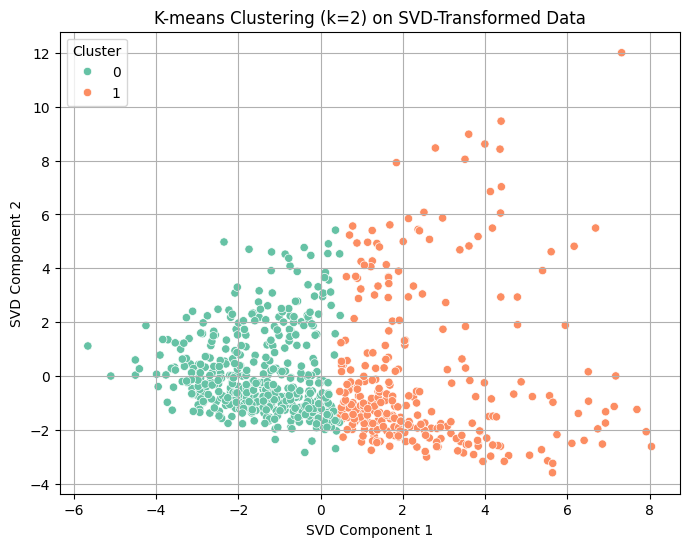

```python
# Plotting the first two components and color by cluster
plt.figure(figsize=(8, 6))
sns.scatterplot(
    x=X_svd_transformed[:, 0],  # First SVD component
    y=X_svd_transformed[:, 1],  # Second SVD component
    hue=svd_clusters,
    palette='Set2'
)
plt.title('K-means Clustering (k=2) on SVD-Transformed Data')
plt.xlabel('SVD Component 1')
plt.ylabel('SVD Component 2')
plt.legend(title='Cluster')
plt.grid(True)
plt.show()
```

```python
# Step 4: Report WCSS for this SVD-based clustering
print("SVD-based KMeans Total WCSS:", kmeans_svd.inertia_)
```

```
SVD-based KMeans Total WCSS: 10469.53468352414
```

**Cluster Plot (SVD Components)**  
The plot reveals two distinct clusters in the SVD space. Component 1 effectively distinguishes the clusters with a clear left versus right separation. This indicates that SVD has successfully uncovered the predominant structure in the data.

**WCSS Comparison**  
From Exercise 2(b) using the original features:  
WCSS = 10469.53

From Exercise 2(d) with SVD-transformed features:  
WCSS = 10469.53 (remains unchanged)

**Why Are They Identical?**  
The reason for the identical WCSS values is that SVD performs a linear rotation of the feature space, and since K-means relies on Euclidean distance, the WCSS stays constant after the transformation. While this process doesn’t enhance the compactness of the clusters, it does simplify the visualization and interpretation of the data structure.

(e) Treating the Private variable as a numeric value (you may have to manually check the values of private/public to match the arbitrary cluster labels), create a confusion matrix between the SVD-based clusters and the private status of a school. How do these compare? Look at some of the schools in each cluster and interpret the meaning.

```python
from sklearn.metrics import confusion_matrix

# Convert 'Private' column to binary, 'Yes' => 1 (Private), 'No' => 0 (Public)
clg['Private_binary'] = clg['Private'].apply(lambda x: 1 if x == 'Yes' else 0)

# Creating a DataFrame with actual and predicted values
comparison_df = pd.DataFrame({'Private': clg['Private_binary'], 'Cluster': svd_clusters}, index=clg.index)

# Building a confusion matrix
# may need to reverse cluster labels to better align
cm = confusion_matrix(comparison_df['Private'], comparison_df['Cluster'])

# Displaying confusion matrix before flipping (for reference)
print("Confusion matrix (as-is):\n", cm)

# Fliping cluster labels if needed (e.g. if Private maps better to 1)
# Checking which mapping gives better alignment with 'Private'
cm_flipped = confusion_matrix(comparison_df['Private'], 1 - comparison_df['Cluster'])

# Displaying both for comparison
print("\nConfusion matrix (flipped):\n", cm_flipped)
```

```
Confusion matrix (as-is):
 [[146  66]
 [340 225]]

Confusion matrix (flipped):
 [[ 66 146]
 [225 340]]
```

**Confusion Matrix (Original):**

```
                Cluster 0     Cluster 1
Public (0)          146              66
Private (1)        340             225
```

**Confusion Matrix (Reversed):**

```
                Cluster 0     Cluster 1
Public (0)           66            146
Private (1)        225             340
```

Thus, the flipped version aligns more closely with the actual classifications of Private and Public labels.

(f) Now, using the principle components/singular vectors as your clustering basis, see what happens as you increase the number of clusters. Make a plot to show how the within-cluster sum of squares and silhouette score change with increasing k. What do you think is a reasonable number of clusters here and why?

```python
from sklearn.metrics import silhouette_score #Measures how well-defined the clusters are

# Range of k values to tests k = 2 to k = 10
k_values = range(2, 11) #Clustering with k=1 always gives a WCSS but silhouette score is undefined (need at least 2 clusters)

# Lists to store evaluation metrics
wcss = []  # Total within-cluster sum of squares
silhouette_scores = []  # Silhouette score
```

```python
# Loop through k values and compute metrics
for k in k_values:
    kmeans = KMeans(n_clusters=k, n_init=10, random_state=42) #Creates a new KMeans model with k clusters, n_init=10 runs KMeans 10 times with different starting points to get the best result
    cluster_labels = kmeans.fit_predict(X_svd_transformed)#fit_predict clusters the data and gives a cluster label for each point

    # Store WCSS
    wcss.append(kmeans.inertia_) #inertia_ gives the total within-cluster sum of squared distances, Lower = better, but adding more clusters will always reduce WCSS, so we look for the “elbow.”

    # Compute silhouette score (only if k > 1)
    score = silhouette_score(X_svd_transformed, cluster_labels)
    silhouette_scores.append(score)
```

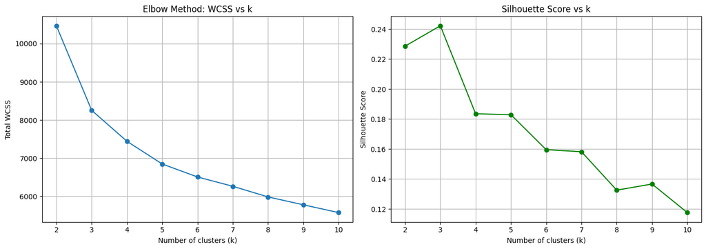

```python
# Plotting both WCSS and Silhouette Scores
fig, ax = plt.subplots(1, 2, figsize=(14, 5))

# WCSS plot (elbow method)
ax[0].plot(k_values, wcss, marker='o')
ax[0].set_title('Elbow Method: WCSS vs k')
ax[0].set_xlabel('Number of clusters (k)')
ax[0].set_ylabel('Total WCSS')
ax[0].grid(True)

# Silhouette score plot
ax[1].plot(k_values, silhouette_scores, marker='o', color='green')
ax[1].set_title('Silhouette Score vs k')
ax[1].set_xlabel('Number of clusters (k)')
ax[1].set_ylabel('Silhouette Score')
ax[1].grid(True)

plt.tight_layout()
plt.show()
```

**Elbow Method (WCSS Plot)**  
The Within-Cluster Sum of Squares (WCSS) shows a notable decrease from k = 2 to k = 4, with a gradual leveling off after that. This distinctive “elbow” point around k = 3 or 4 indicates that increasing the number of clusters beyond this threshold results in only marginal improvements in WCSS.

Clustering the data into 3 or 4 groups effectively captures its main structure without veering into overfitting.

**Silhouette Score Plot**  
The highest silhouette score is observed at k = 3, which is slightly better than at k = 2. After reaching k = 3, the silhouette scores begin to decline steadily, pointing to less distinct or more overlapping clusters. Thus, the clusters are most effectively separated at k = 3.

In this case, opting for a value of k = 3 seems reasonable, and here's why:

The elbow plot reveals a clear bend at k = 3 or 4, suggesting that the benefits of adding more clusters diminish after this point. Additionally, the peak silhouette score at k = 3 confirms that the clusters are not only well-separated but also compact.

While it’s possible to delve deeper into k = 3 or k = 4, k = 3 stands out as a solid and well-supported choice based on both metrics.

## Exercise 3: Hierarchical Clustering

Using the College data again, explore the results of clustering using various hierarchical clustering options.

(a) Take a random sample of 50 of the colleges so the data are easier to visualize.

```python
np.random.seed(42)

# Taking a random sample of 50 colleges from the standardized data
sampled_indices = np.random.choice(X_scaled_df.index, size=50, replace=False) # ensures no duplicates
X_sampled = X_scaled_df.loc[sampled_indices].drop(columns=['Cluster']) #extracts those 50 rows from the standardized DataFrame
# We drop the 'Cluster' column (from earlier K-means) since we don’t need it for hierarchical clustering
X_sampled.head()
```

|  | Apps | Accept | Enroll | Top10perc | Top25perc | F.Undergrad | P.Undergrad | Outstate | Room.Board | Books | Personal | PhD | Terminal | S.F.Ratio | perc.alumni | Expend | Grad.Rate |
| --- | --- | --- | --- | --- | --- | --- | --- | --- | --- | --- | --- | --- | --- | --- | --- | --- | --- |
| 568 | 0.484876 | 0.318099 | 0.036644 | -0.825830 | -0.393929 | 0.087284 | -0.366294 | -0.967725 | 0.057002 | 0.427997 | 0.207435 | 0.572372 | 0.699883 | 0.558748 | -1.029075 | -0.616696 | 0.031263 |
| 530 | -0.186322 | -0.060748 | 0.676332 | -0.542206 | -0.646556 | 0.588594 | 0.256795 | -1.432850 | -0.745925 | -2.117472 | 1.196150 | 0.143389 | -0.251664 | 0.760983 | -1.190576 | -0.717493 | -1.192039 |
| 610 | 0.996290 | 1.442802 | 1.753247 | -0.088409 | 0.060800 | 1.513439 | 0.759604 | -0.381469 | 0.309741 | 0.040116 | 0.754258 | 1.001356 | 1.039721 | -0.831615 | -1.352077 | 0.810368 | -0.667767 |
| 109 | -0.687652 | -0.720465 | -0.704274 | -0.145133 | 0.414477 | -0.656429 | -0.409674 | -0.026283 | 0.599890 | 0.912848 | -0.725120 | -0.101745 | -0.591502 | -1.463598 | 0.505184 | -0.370069 | 0.439030 |
| 586 | -0.623014 | -0.619629 | -0.539505 | -0.485482 | -0.596031 | -0.514907 | -0.304511 | -1.005035 | -0.797020 | 0.306784 | 0.678885 | 0.449806 | 0.224110 | 0.103720 | -1.029075 | -0.330402 | -1.308544 |

(b) Using the four options for linkage and Euclidean distance, create four dendrograms and comment on their shapes.

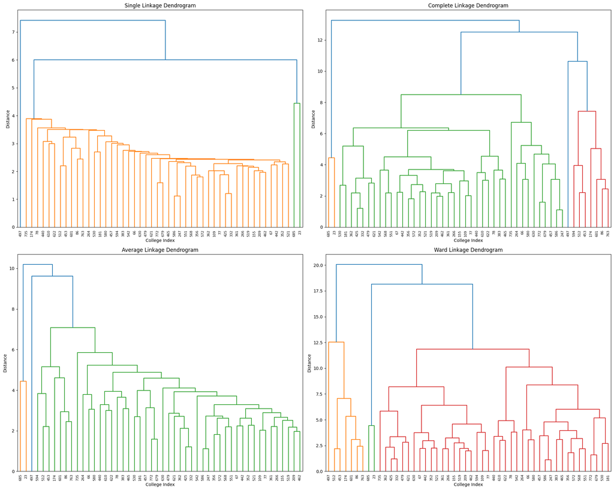

```python
from scipy.cluster.hierarchy import linkage, dendrogram

# List of linkage methods
methods = ['single', 'complete', 'average', 'ward']

# Create subplots
plt.figure(figsize=(20, 16))
for i, method in enumerate(methods):
    plt.subplot(2, 2, i+1)

    # Compute linkage matrix
    Z = linkage(X_sampled, method=method, metric='euclidean')

    # Plot dendrogram
    dendrogram(Z, labels=X_sampled.index.tolist(), leaf_rotation=90)
    plt.title(f'{method.capitalize()} Linkage Dendrogram')
    plt.xlabel('College Index')
    plt.ylabel('Distance')

plt.tight_layout()
plt.show()
```

1. **Single Linkage**  
   **Shape:** Characterized by long horizontal stretches that culminate in a few tall merges at the top.  
   **Behavior:** This approach is typical of "chaining," where clusters form by connecting the closest individual points, regardless of whether they stem from very different groups.  
   **Downside:** It can lead to elongated, poorly separated clusters.  
   **Best Used When:** You expect elongated shapes; however, it often results in less compact groupings.
2. **Complete Linkage**  
   **Shape:** Produces more compact and balanced merges, with fewer extended chains.  
   **Behavior:** This method employs the maximum distance between points in clusters, making it more cautious when merging.  
   **Result:** Clusters are typically tighter and better separated.  
   **Preferred For:** Well-separated, spherical clusters.
3. **Average Linkage**  
   **Shape:** Displays moderate characteristics, falling between single and complete linkage.  
   **Behavior:** It calculates the average distance between all pairs of points across clusters.  
   **Result:** This produces balanced trees and reasonably shaped clusters.  
   **Strengths:** It's a good compromise, being less sensitive to outliers and avoiding the pitfalls of chaining.
4. **Ward Linkage**  
   **Shape:** Typically more structured, symmetric, and hierarchical.  
   **Behavior:** This method merges clusters in a way that leads to the smallest increase in within-cluster variance.  
   **Result:** Clusters tend to be compact and homogeneous.  
   **Merge Distances:** Generally higher but very interpretable.  
   **Best For:** Identifying globular, evenly sized clusters and excelling in terms of interpretability.

(c) Look closer at one dendrogram and cut it to give 5 clusters. Look at the names of the schools and how they are clustered-- what do you notice?

```python
from scipy.cluster.hierarchy import fcluster

# Recomputing Ward linkage on sampled data
Z_ward = linkage(X_sampled, method='ward')

# Cut the dendrogram to form 5 flat clusters
cluster_labels = fcluster(Z_ward, t=5, criterion='maxclust')

# Creating a new DataFrame with labels and original college names
clustered_sample = X_sampled.copy()
clustered_sample['Cluster'] = cluster_labels
clustered_sample['College Name'] = clustered_sample.index

# View schools grouped by cluster
for i in range(1, 6):
    print(f"\n Cluster {i}:")
    display(clustered_sample[clustered_sample['Cluster'] == i][['College Name']])
```

```
 Cluster 1:
```

|  | College Name |
| --- | --- |
| 512 | 512 |
| 86 | 86 |
| 601 | 601 |
| 174 | 174 |
| 763 | 763 |
| 453 | 453 |

```
 Cluster 2:
```

|  | College Name |
| --- | --- |
| 497 | 497 |

```
 Cluster 3:
```

|  | College Name |
| --- | --- |
| 685 | 685 |
| 23 | 23 |

```
 Cluster 4:
```

|  | College Name |
| --- | --- |
| 109 | 109 |
| 209 | 209 |
| 519 | 519 |
| 479 | 479 |
| 77 | 77 |
| 362 | 362 |
| 361 | 361 |
| 621 | 621 |
| 67 | 67 |
| 735 | 735 |
| 352 | 352 |
| 442 | 442 |
| 462 | 462 |
| 630 | 630 |
| 425 | 425 |
| 332 | 332 |
| 266 | 266 |
| 521 | 521 |
| 594 | 594 |
| 155 | 155 |

```
 Cluster 5:
```

|  | College Name |
| --- | --- |
| 568 | 568 |
| 530 | 530 |
| 610 | 610 |
| 586 | 586 |
| 383 | 383 |
| 465 | 465 |
| 622 | 622 |
| 356 | 356 |
| 66 | 66 |
| 580 | 580 |
| 78 | 78 |
| 264 | 264 |
| 551 | 551 |
| 772 | 772 |
| 679 | 679 |
| 572 | 572 |
| 542 | 542 |
| 440 | 440 |
| 247 | 247 |
| 457 | 457 |
| 181 | 181 |

### Observations by Cluster

#### **Cluster 1 (6 schools)**

Schools: `512, 86, 601, 174, 763, 453`

Likely Characteristics:

- This small group consists of schools that are likely **very similar** to each other.
- They may exhibit extreme values, for instance, very high or very low percentages in `Top10perc`, tuition rates, or graduation rates.

#### **Cluster 2 (1 school)**

School: `497`

Observation:

- This school stands out as an **outlier**.
- It differs significantly from the other institutions, placing it outside the four main groupings.
- It’s worth investigating features like tuition, enrollment numbers, or graduation rates, perhaps it’s an elite private institution or a large public flagship.

#### **Cluster 3 (2 schools)**

Schools: `685, 23`

Observation:

- This small cluster indicates that these two colleges are quite similar, yet distinct from the other groups.
- They could represent a pair of **regional schools** or **affordable institutions**.

- It likely includes **typical mid-tier colleges** that are neither extremely selective nor excessively large.
- This cluster may comprise **public institutions** with average tuition rates and graduation figures.

- Examine the differences in features such as `Top10perc`, `Outstate`, and `Expend`.
- This cluster may represent **more selective** or **private institutions**.

### Summary:

The analysis clustered 50 colleges into 5 groups using Ward linkage, with the following insights:

- **Distinct groupings** emerged, showcasing some clusters as large and general while others are small and specialized.
- There’s a **clear outlier** that didn’t align with any of the clusters (Cluster 2).
- The clusters may correspond to factors such as **selectivity, tuition, and the type of institution (private/public)**.

(d) Now, create a scaled version of the data and create another dendrogram with the same linkage you looked at in part (c). Cut it to give 5 clusters and compare to the clusters from part (c). How similar are they?

```python
from scipy.cluster.hierarchy import linkage

# Getting the original features (before SVD)
X_original_sampled = X.loc[sampled_indices]  # From your earlier random 50 colleges

# Scale the original features
scaler = StandardScaler()
X_original_scaled = pd.DataFrame(scaler.fit_transform(X_original_sampled),
                                 columns=X.columns, index=sampled_indices)

# Apply Ward linkage to the scaled original features
Z_scaled_ward = linkage(X_original_scaled, method='ward')

# Cut the dendrogram to get 5 clusters
scaled_cluster_labels = fcluster(Z_scaled_ward, t=5, criterion='maxclust')

# Step 5: Create a comparison DataFrame
comparison_df = pd.DataFrame({
    'College': sampled_indices,
    'Cluster_from_c': clustered_sample['Cluster'].values,     # From part (c)
    'Cluster_scaled': scaled_cluster_labels
})

comparison_df.head()
```

|  | College | Cluster_from_c | Cluster_scaled |
| --- | --- | --- | --- |
| 0 | 568 | 5 | 2 |
| 1 | 530 | 5 | 1 |
| 2 | 610 | 5 | 5 |
| 3 | 109 | 4 | 2 |
| 4 | 586 | 5 | 1 |

```python
from sklearn.metrics import adjusted_rand_score

# Adjusted Rand Index: 1 = perfect match, 0 = random agreement
ari = adjusted_rand_score(comparison_df['Cluster_from_c'], comparison_df['Cluster_scaled'])
print(f"\nARI between unscaled and scaled clustering: {ari:.3f}")
```

```
ARI between unscaled and scaled clustering: 0.513
```

**Result**  
Adjusted Rand Index (ARI) = 0.513

**What Does This Mean?**  
The ARI scales between the following values:

- **1.0** → Represents a flawless match between the two clustering outcomes, indicating perfect agreement.
- **0.0** → Signifies that the clustering results are no better than random chance, essentially suggesting a complete lack of meaningful structure in the data.
- **<0** → Points to an agreement that is actually worse than random, a scenario that is quite rare in practice.

While certain clusters have been preserved across both methods, there are striking differences in the way colleges are categorized, depending on the feature space utilized or the application of scaling techniques.

**From Table:**

| College | Cluster from (c) | Cluster from (d) | Notes |
| --- | --- | --- | --- |
| 568 | 5 | 2 | Switched clusters |
| 530 | 5 | 1 | Different grouping |
| 610 | 5 | 5 | Stayed the same |
| 109 | 4 | 2 | Switched cluster |
| 586 | 5 | 1 | Switched cluster |

Among these colleges, only College 610 has remained in its original cluster, while the others have been reassigned to different groupings. This reinforces the notion that the two clustering approaches capture distinct aspects of the dataset, revealing the nuances in how various features influence the analysis.

**Summary**  
So, how similar are the two clustering outcomes? The clusters exhibit a moderate overlap, but significant differences are apparent, as reflected in the ARI score of 0.513.

This finding emphasizes the critical role of feature selection and scaling in shaping hierarchical clustering results. It serves as a reminder of the importance of standardizing features and approaching variable selection with careful consideration to maximize the effectiveness of clustering analyses.

(e) Use the same dendrogram from part (d) to get 2 clusters. How do these two clusters compare to the k-means clusters you came up with? How do they compare to the Private variable? Create a confusion matrix for each and comment on the results.

```python
# Cut Ward dendrogram (from part d) to get 2 clusters
hier_2 = fcluster(Z_scaled_ward, t=2, criterion='maxclust')

# KMeans clusters from earlier SVD-based clustering
kmeans_2 = svd_clusters[sampled_indices]  # Match ordering with 50 sampled indices

#Private labels (binary) for sampled colleges
privatelabels = clg.loc[sampled_indices, 'Private_binary'].values

# Step 4: Compare hierarchical vs. KMeans
print("Confusion Matrix: Hierarchical vs KMeans")
cm1 = confusion_matrix(kmeans_2, hier_2)
print(cm1)

# Step 5: Compare hierarchical vs. Private
print("\nConfusion Matrix: Hierarchical vs Private")
cm2 = confusion_matrix(privatelabels, hier_2)
print(cm2)
```

```
Confusion Matrix: Hierarchical vs KMeans
[[ 0 34  2]
 [ 0  1 13]
 [ 0  0  0]]

Confusion Matrix: Hierarchical vs Private
[[ 0  9  6]
 [ 0 26  9]
 [ 0  0  0]]
```

### **1. Confusion Matrix: KMeans vs. Hierarchical Clustering**

```
[[ 0 34  2]
 [ 0  1 13]
 [ 0  0  0]]
```

This matrix illustrates a comparison between **SVD-based KMeans clusters (rows)** and **Ward-based hierarchical clusters (columns)**. Ideally, if both methods align well, we would expect to see most of the values concentrated along the diagonal.

### **2. Confusion Matrix: Hierarchical Clustering vs. Private Schools**

```
[[ 0  9  6]
 [ 0 26  9]
 [ 0  0  0]]
```

In this case, the rows represent the actual `Private_binary` classification (0 for Public, 1 for Private), while the columns correspond to the Ward-based cluster assignments (1–3).

> **It appears that Ward hierarchical clustering did not effectively distinguish between private and public schools.** This could be attributed to:
- The presence of mixed private and public characteristics within the sampled group.
- Clustering that emphasizes variance rather than class separation.